# Nasil reproducible research yaparim

Diyelim ki bir arkadasiniz yaklasik bir sene once tamamlamis oldugunuz bir *research* calismanizdan birsey sordu. Calismaniza donup analizleri tekrar gozden gecirmek, tablo ve figurlerin *reproduce* edebilmeniz ne kadar vaktinizi alacaktir? Veya arkadasinizi bosverin, sadece kendiniz 2 sene once hazirlamis oldugunuz sunumdaki *result*larin tekrar elde etmeye calissaniz? Bu sureyi ve olasi zahmeti azaltmanin (ve daha fazlasi) metodu *reproducible research* yapmaniz!

Eger gunluk hayattaki calismalarinizda bir sekilde *data analysis* yapiyorsaniz, eski yontemler yerine *reproducible research* kullanmaniz belki biraz daha zahmetli ama uzun vadede kesinlikle daha faydali.

Bir baska acidan bakacak olursak, geleneksel rapor yaziminda, sonuclari bir software de hesaplayip, sonra da hesaplamis oldugumuz sayilari elle sonuc bolumune yazariz. Ama bu yontem reproducible degil, data *software* e bagli fakat sonuclar yazdigimiz metine bagli degil, dolayisiyla hata yapma ihtimali bayagi yuksek.

Bu konu tabiiki bayagi genis ve kapsamli, ayrica niyetim bir *manual* yazmak degil. Bu yazida amacim kendi tecrubelerimden faydalanarak tamamen pratik acidan reproducible research’u kisaca anlatmaya calismak ([daha ayrintili bilgi icin tiklayin](http://reproducibleresearch.net)). Turkce yazmamin amaci da bu konulardaki Turkce materyallerin eksigligi.

Ilk olarak data analysis’i hangi *software* de yapacagim sorusu karsimiza geliyor. Bir istatistikci oldugum icin buna verecegim cevap tabiki **R** (since **R** is made by statisticians for statisticians!). Ikinci olarak *typesetting* programimizi belirlememiz gerekiyor, raporu/makaleyi/tezi yazacagimiz veya sunumu hazirlayacagimiz program. Buna cevabimiz ise LaTeX oluyor. Ve ucuncu olarak bize uygun bir *text editor* gerekli, bunun icin de **Rstudio** yu kullaniyoruz. Sonunda sihirli dokunusu yapacak yani reproducible research u mumkun kilacak olan program (aslinda bir **R** *package*): **knitr**. Tam burada **knitr** in babasi olan programi hatirlatmam gerekiyor, saygi geregi **Sweave**.

## Basit bir ornek

*Base R* dan *cars* adli *dataset* i kullanacagiz. Bu dataset farkli arabalarin hizlari (*speed variable*) ve her bir arabanin durmak icin gerekli mesafelerini (*dist variable*) iceriyor. Bu datayi analiz etmek icin *linear regression* kullaniyoruz ve gerekli **R** kodu asagidaki gibi gosterebiliriz.

```r
fit <- lm(dist ~ speed, data = cars) # linear regression
```

```r
library(knitr)
coefs <- matrix(coef(fit))
rownames(coefs) <- c("Intercept", "speed")
kable(coefs, label = "tab:coefs",
      digits = 2,
      row.names = TRUE,
      col.names = "Estimate")
```

|  | Estimate |
| --- | --- |
| Intercept | -17.58 |
| speed | 3.93 |

Normal sartlarda tabloyu yaratan **R** kodu okuyucuya gostermeye gerek yok fakat ben ornek olmasi acisindan gosteriyorum.

Simdi ise *data visualization*. Asagidaki **R** kod ile Figure 1’i elde ediyoruz.

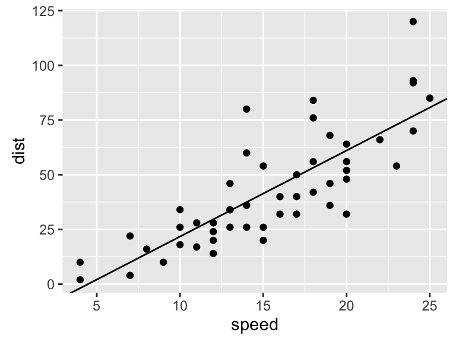

```r
library(ggplot2)
ggplot(cars, aes(x = speed, y = dist)) + geom_point() +
    geom_abline(intercept = coef(fit)[1], slope = coef(fit)[2])
```

Benim ugrastigim problemlerde **knitr** in saglamis oldugu cok onemli diger bir fayda ise *cache* ozelligi. Simdi farz edin ki analiziniz yukaridaki gibi bir simple linear regression degil, mesela simulasyon yapiyorsunuz veya *bootstrapping*. Dolayisiyla islem saatler surebilir. Bu durumda **knitr** in cache ozelligini kullanabilirsiniz, ilk compilation da analiz yapilir (artik ne kadar suruyorsa) ve **knitr** sizin icin outputu kaydeder. Sonraki compilationlarda ise knitr kaydedilmis outputu kullanir!

Bu arada **knitr**’i her turlu farkli LaTeX *documentclass* icin kullanabilirsiniz, mesela rapor yazarken veya sunumunuzu hazirlarken. Diyelim ki sunumunuzdaki bir analizde kucuk bir degisiklik yapmak istiyorsunuz, artik cok kolay ve pratik bir sekilde bunu yapabilirsiniz.

## Kapanis

Daha once soyledigim gibi **knitr** bayagi flexible. Mesela LaTeX kullanmak istemiyorsaniz, **R** + **Markdown** + **Rstudio** da gayet guzel bir alternatif sizin icin. Boylece HTML ve ya Word output da elde edebilirsiniz, PDF in yaninda (ozellikle LaTeX bilmiyorsaniz). Veyahut **R** yerine **Phyton**, **SAS**, **Ruby** kullanabilirsiniz, **Rstudio** yerine **LyX**, **Texmaker** veya **Emacs** kullanabilirsiniz. Fakat bence **Rstudio** dan sasmamak en mantiklisi cunku Rstudio knitr icin *build-in support* a sahip. Muhtemelen bunun onemli bir nedeni **knitr** in yaraticisinin bir **Rstudio** calisani olmasi. Hepsi ve daha fazlasi icin [**knitr** in websitesine bakabilirsiniz](http://yihui.name/knitr/). Son olarak, bu yazinin kendisi de **knitr** kullanarak reproducible researche bir ornek, source code u yazardan taleb edebilirsiniz.